# Assessment3

# Introduction

This research of final project focus to analyse crime patterns within the East End Base Command Unit (BCU), which covers the London boroughs of Redbridge, Havering and Barking & Dagenham. It aims to gain insight into the spatial and time distribution of crime within these boroughs, in particular identifying high crime areas. Also, we will analyse the relationship between crime rates and socio-economic factors such as deprivation, and assessing vehicle theft rates across boroughs. By combining crime data from 2022, population data and deprivation data, we will answer a range of questions that are important in guiding police deployment strategies, community safety plans and local policy development. This research hopes to help guide the allocation of resources and interventions within the East End BCU, thereby improving public safety and reducing crime within these boroughs.

```r
# Load packages
library(ggspatial)
library(sf)
library(readr)
library(readxl)
library(tidyverse)
library(kableExtra)
```

```r
# Read the datasets
london_crimes <- read.csv("london_crimes.csv") |>
  st_as_sf(coords = c("longitude", "latitude"), crs = 4326) |>
  st_transform(crs = "EPSG:27700")

london_population <- read.csv("housing-density-ward.csv") |>
  filter(Year == 2022) |>
  select(Ward_Name, Population)

london_deprivation <- read.csv("gla-deprivation-indices-ward-2007.csv")  |>
  select(Ward.name, Extent)

london_ward <- st_read("ESRI/London_Ward.shp") |>
  st_transform(crs = "EPSG:27700")
# Filter the boroughs in the East Area BCU
east_wards <- london_ward |>
  filter(BOROUGH %in% c("Redbridge", "Havering", "Barking and Dagenham"))

# Merget the dataste
east_crimes <- london_crimes |>
  st_join(east_wards, join = st_intersects, left = FALSE) |>
  left_join(london_population, by = c("NAME" = "Ward_Name")) |>
  left_join(london_deprivation, by = c("NAME" = "Ward.name"))
```

# Data Analysis

## Study on the crimes distribution and types of crime locations

### Crime distribution

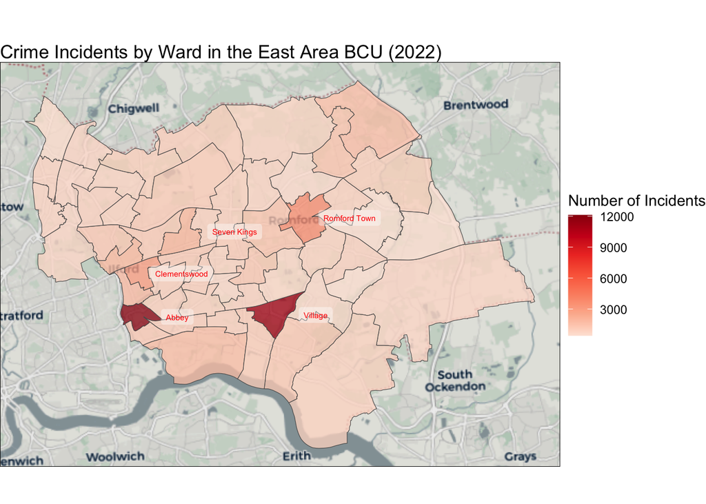

```r
# Calculate the counts of crime incidents per ward
crime_counts <- east_crimes |>
  st_drop_geometry() |>
  count(NAME, name = "count")

# Join the crime counts back to ward boundaries
ward_counts <- east_wards |>
  left_join(crime_counts, by = "NAME") |>
  replace_na(list(count = 0))

# Find the ward with the top 5 number of incidents
top_count <- ward_counts |>
  arrange(desc(count)) |>
  slice(1:5)

# Plot the map showing the incidence of crimes by ward
ggplot(ward_counts) +
  annotation_map_tile(type = "cartolight", zoomin = 0, progress = "none") +
  geom_sf(aes(fill = count), alpha = 0.75) +
  scale_fill_distiller(palette = "Reds", direction = 1) +
  labs(
    title = "Crime Incidents by Ward in the East Area BCU (2022)",
    fill = "Number of Incidents"
  ) +
  theme_void() +
  theme(panel.border = element_rect(colour = "black", fill = NA)) +
  geom_sf_label(
    aes(label = NAME),
    data = top_count,
    alpha = 0.4,
    colour = "red",
    lineheight = 1,
    size = 2,
    label.size = NA,
    nudge_x = 2000
  )
```

The above map shows the distribution of crime incidents in each constituency in the Eastern BCU (Basic Command Unit) in 2022. The map uses color depth to represent the number of crime incidents, and the darker the color, the more crime incidents there are in the constituency. The results show that Abbey, Clementswood, Village, Romford Town and Seven Kings are the five constituencies with the most crime incidents, and these areas should be the focus of the police. Due to the high crime rate in these areas, it is recommended to strengthen the deployment of police forces in these areas to effectively combat criminal activities and improve community safety.

### Type distribution

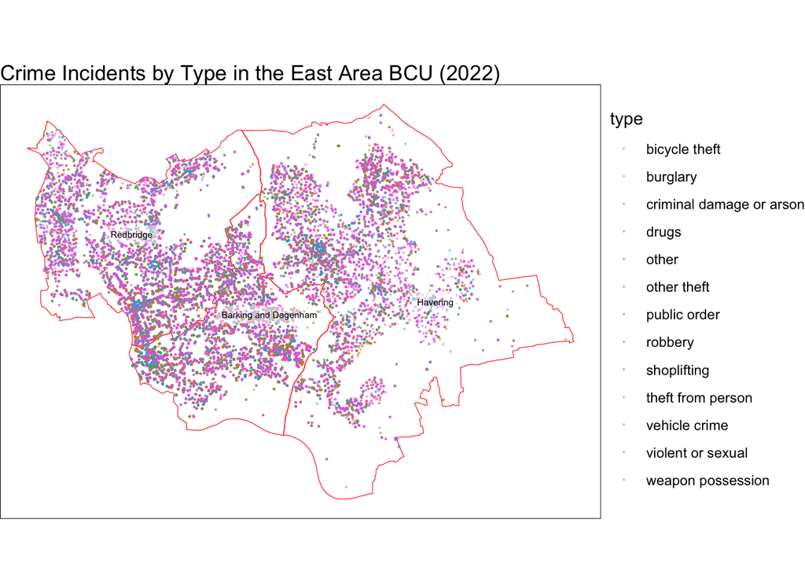

```r
# Calculate the borough boundaries by grouping wards
borough_boundaries <- east_wards |>
  group_by(BOROUGH) |>
  summarise(geometry = st_union(geometry)) |>
  ungroup()

# Plot the map
ggplot() +
  # Plot the borough boundaries
  geom_sf(data = borough_boundaries, fill = NA, colour = "red", size = 1) +
  geom_sf(
    data = east_crimes,
    aes(color = type),
    alpha = 0.4,
    size = 0.1
  ) +
  geom_sf_label(
    aes(label = BOROUGH),
    data = borough_boundaries,
    alpha = 0.5,
    colour = "black",
    lineheight = 1,
    size = 2,
    label.size = NA
  ) +
  labs(
    title = "Crime Incidents by Type in the East Area BCU (2022)",
    shape = "Type of Crime"
  ) +
  theme_void() +
  theme(panel.border = element_rect(colour = "black", fill = NA))
```

In the above map, the geographical distribution of different types of crime within the East BCU is clearly shown. It can be seen that vehicle crime and violent or sexual crime are widely distributed throughout the region, especially in the three administrative districts of Redbridge, Barking and Dagenham.

Specifically, vehicle crime is mainly concentrated near main roads with dense traffic and residential areas, while violent or sexual crimes are more likely to occur around commercial areas and densely populated residential areas. These crime hotspots may be closely related to population density, socioeconomic conditions, and the layout of public facilities.

### Location distribution

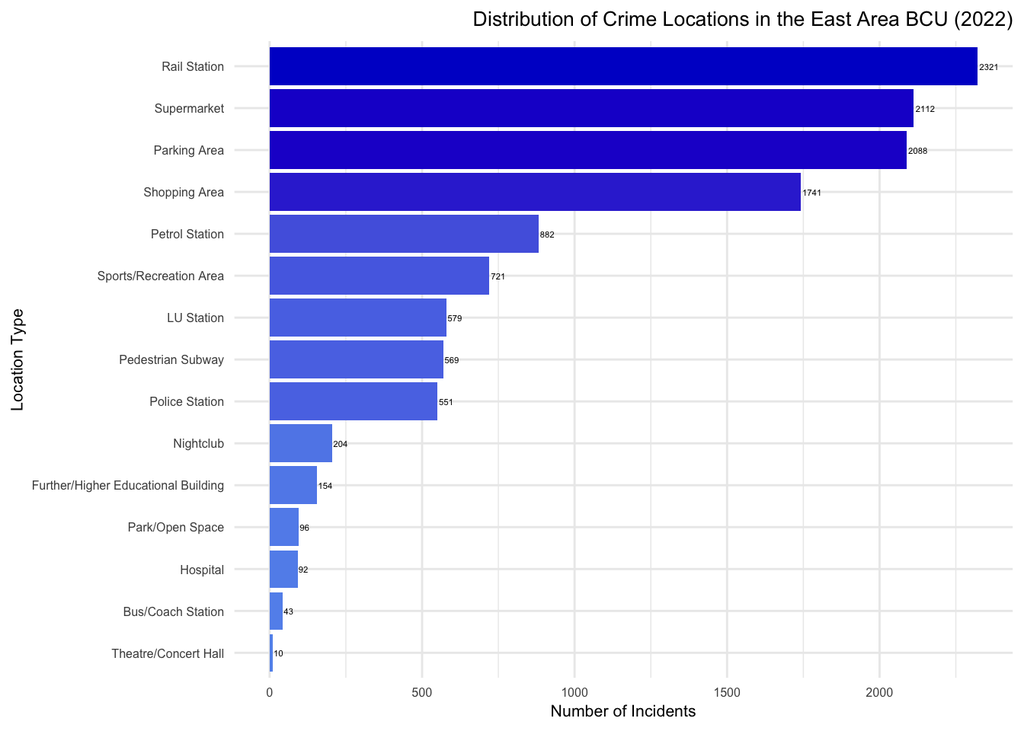

```r
# Count the occurrences of each location type
location_type_counts <- east_crimes |>
  st_drop_geometry() |>
  group_by(location_type) |>
  summarise(count = n()) |>
  na.omit() |>
  arrange(desc(count))

# Create a bar plot to visualize the crime locations in the East Area BCU
ggplot(location_type_counts, aes(x = reorder(location_type, count), y = count)) +
  geom_bar(aes(fill = count), stat = "identity") +
  geom_text(aes(label = count), hjust = -0.1, cex = 1.5) +
  scale_fill_gradient(low = "cornflowerblue", high = "mediumblue") +
  coord_flip() +
  labs(
    title = "Distribution of Crime Locations in the East Area BCU (2022)",
    x = "Location Type",
    y = "Number of Incidents"
  ) +
  theme_minimal() +
  theme(legend.position = "none",
        plot.title = element_text(hjust = 1, size = 10),
        axis.text = element_text(size = 6),
        axis.title = element_text(size = 8))
```

The above figure shows the distribution of different crime locations in the Eastern BCU in 2022. The data shows that railway stations, supermarkets and parking lots are the locations where the most crimes occurred, and the number of crimes in these locations is significantly higher than other types of locations. This indicates that these areas are hotspots of criminal activity and may require increased police deployment. In contrast, bus stations and theaters/concert halls have the least criminal incidents, indicating that these locations may not require too much police attention.

### Ward and Crime type

```r
# Assuming you have a summarized dataset with counts of each crime type per ward
east_crimes %>%
  st_drop_geometry() %>%
  count(NAME, type) %>%
  pivot_wider(names_from = type, values_from = n) %>%
  replace_na(list(n = 0)) %>%
  kable()
```

| NAME | bicycle theft | burglary | criminal damage or arson | drugs | other | other theft | public order | robbery | shoplifting | theft from person | vehicle crime | violent or sexual | weapon possession |
| --- | --- | --- | --- | --- | --- | --- | --- | --- | --- | --- | --- | --- | --- |
| Abbey | 112 | 424 | 656 | 1336 | 148 | 1600 | 932 | 496 | 740 | 1028 | 936 | 3588 | 108 |
| Aldborough | 16 | 60 | 61 | 51 | 21 | 120 | 67 | 19 | 53 | 38 | 290 | 359 | 7 |
| Alibon | 8 | 54 | 70 | 76 | 17 | 94 | 68 | 26 | 29 | 26 | 99 | 341 | 5 |
| Barkingside | 5 | 61 | 49 | 36 | 14 | 61 | 61 | 18 | 37 | 17 | 237 | 250 | 4 |
| Becontree | 4 | 61 | 99 | 50 | 14 | 93 | 64 | 21 | 13 | 11 | 124 | 449 | 4 |
| Bridge | 8 | 50 | 66 | 24 | 9 | 82 | 45 | 19 | 37 | 11 | 179 | 246 | 3 |
| Brooklands | 12 | 75 | 128 | 69 | 22 | 148 | 126 | 11 | 23 | 19 | 209 | 591 | 6 |
| Chadwell | 2 | 65 | 82 | 34 | 11 | 97 | 61 | 24 | 38 | 13 | 163 | 340 | 2 |
| Chadwell Heath | 8 | 49 | 75 | 56 | 13 | 76 | 76 | 26 | 22 | 10 | 186 | 362 | 11 |
| Church End | 10 | 63 | 40 | 21 | 7 | 142 | 42 | 24 | 71 | 25 | 186 | 201 | NA |
| Clayhall | 7 | 41 | 54 | 29 | 13 | 65 | 49 | 13 | 93 | 15 | 266 | 227 | 3 |
| Clementswood | 38 | 119 | 165 | 157 | 34 | 437 | 167 | 134 | 281 | 361 | 259 | 763 | 17 |
| Cranbrook | 12 | 55 | 61 | 70 | 13 | 224 | 84 | 29 | 43 | 34 | 209 | 415 | 3 |
| Cranham | 6 | 23 | 47 | 12 | 9 | 32 | 36 | 14 | 11 | 9 | 105 | 156 | 1 |
| Eastbrook | 10 | 40 | 74 | 58 | 7 | 70 | 55 | 17 | 15 | 10 | 96 | 260 | 7 |
| Eastbury | 5 | 62 | 89 | 52 | 18 | 151 | 56 | 28 | 13 | 14 | 144 | 419 | 5 |
| Elm Park | 3 | 48 | 63 | 37 | 11 | 50 | 49 | 15 | 47 | 10 | 74 | 260 | 6 |
| Emerson Park | 2 | 23 | 18 | 12 | 7 | 43 | 23 | 4 | 15 | 1 | 122 | 175 | 5 |
| Fairlop | 8 | 54 | 69 | 30 | 15 | 111 | 71 | 30 | 56 | 42 | 204 | 295 | 8 |
| Fullwell | 5 | 64 | 48 | 30 | 9 | 96 | 51 | 25 | 30 | 23 | 139 | 267 | 11 |
| Gascoigne | 6 | 68 | 91 | 109 | 19 | 198 | 91 | 25 | 17 | 22 | 172 | 373 | 7 |
| Goodmayes | 9 | 64 | 80 | 73 | 17 | 134 | 87 | 40 | 10 | 31 | 169 | 435 | 16 |
| Gooshays | 8 | 138 | 170 | 70 | 23 | 131 | 114 | 28 | 77 | 16 | 228 | 649 | 6 |
| Goresbrook | 15 | 50 | 82 | 42 | 24 | 73 | 60 | 48 | 28 | 18 | 124 | 413 | 6 |
| Hacton | 1 | 28 | 34 | 16 | 12 | 36 | 17 | 6 | 27 | 11 | 82 | 142 | 10 |
| Hainault | 11 | 64 | 69 | 30 | 18 | 143 | 70 | 20 | 36 | 10 | 148 | 380 | 5 |
| Harold Wood | 25 | 87 | 72 | 40 | 18 | 111 | 56 | 13 | 47 | 10 | 206 | 301 | 2 |
| Havering Park | 2 | 42 | 73 | 30 | 12 | 69 | 69 | 4 | 2 | 4 | 121 | 379 | 6 |
| Heath | 12 | 64 | 102 | 69 | 15 | 146 | 102 | 31 | 13 | 10 | 179 | 530 | 4 |
| Heaton | 6 | 110 | 135 | 62 | 24 | 131 | 99 | 17 | 86 | 8 | 247 | 523 | 10 |
| Hylands | 6 | 34 | 52 | 37 | 20 | 129 | 40 | 16 | 33 | 2 | 264 | 218 | 5 |
| Longbridge | 3 | 40 | 50 | 114 | 14 | 89 | 53 | 45 | 113 | 26 | 162 | 273 | 4 |
| Loxford | 17 | 94 | 127 | 100 | 21 | 211 | 114 | 63 | 27 | 85 | 235 | 648 | 8 |
| Mawneys | 3 | 57 | 67 | 35 | 10 | 119 | 51 | 9 | 42 | 3 | 140 | 258 | 3 |
| Mayesbrook | 10 | 73 | 65 | 46 | 22 | 87 | 54 | 52 | 53 | 21 | 137 | 320 | 3 |
| Mayfield | 1 | 52 | 74 | 48 | 10 | 103 | 52 | 24 | 9 | 18 | 215 | 370 | 5 |
| Monkhams | 2 | 49 | 29 | 13 | 3 | 57 | 31 | 16 | 45 | 5 | 133 | 139 | 1 |
| Newbury | 5 | 63 | 67 | 69 | 23 | 174 | 71 | 45 | 59 | 14 | 198 | 362 | 2 |
| Parsloes | 2 | 46 | 44 | 25 | 14 | 63 | 42 | 17 | 40 | 10 | 103 | 251 | 4 |
| Pettits | 1 | 30 | 46 | 25 | 11 | 54 | 45 | 4 | 21 | 8 | 126 | 216 | 2 |
| Rainham and Wennington | 3 | 49 | 77 | 52 | 15 | 71 | 45 | 19 | 40 | 5 | 245 | 304 | 5 |
| River | 12 | 80 | 90 | 64 | 17 | 103 | 77 | 22 | 11 | 16 | 174 | 428 | 7 |
| Roding | 7 | 67 | 39 | 16 | 7 | 118 | 44 | 10 | 12 | 4 | 244 | 209 | 2 |
| Romford Town | 40 | 100 | 221 | 268 | 33 | 452 | 307 | 101 | 460 | 239 | 250 | 1134 | 47 |
| Seven Kings | 14 | 100 | 168 | 91 | 21 | 191 | 116 | 39 | 71 | 33 | 187 | 925 | 12 |
| Snaresbrook | 17 | 55 | 60 | 26 | 10 | 76 | 57 | 19 | 51 | 23 | 220 | 177 | 4 |
| South Hornchurch | 9 | 95 | 111 | 58 | 25 | 156 | 89 | 18 | 17 | 9 | 209 | 473 | 9 |
| Squirrel's Heath | 6 | 62 | 70 | 26 | 12 | 72 | 56 | 13 | 102 | 11 | 240 | 246 | 7 |
| St. Andrew's | 3 | 36 | 69 | 31 | 8 | 129 | 69 | 28 | 46 | 23 | 154 | 276 | 6 |
| Thames | 20 | 109 | 119 | 96 | 21 | 177 | 90 | 43 | 81 | 18 | 362 | 583 | 11 |
| Upminster | 5 | 40 | 47 | 30 | 13 | 104 | 46 | 22 | 100 | 52 | 135 | 174 | 2 |
| Valence | 1 | 54 | 67 | 26 | 9 | 155 | 39 | 22 | 5 | 4 | 127 | 341 | 5 |
| Valentines | 13 | 92 | 95 | 114 | 18 | 234 | 134 | 68 | 110 | 156 | 179 | 633 | 11 |
| Village | 108 | 639 | 846 | 792 | 216 | 1044 | 738 | 243 | 540 | 351 | 1260 | 4266 | 90 |
| Wanstead | 14 | 57 | 44 | 28 | 10 | 53 | 42 | 20 | 2 | 17 | 208 | 225 | 5 |
| Whalebone | 18 | 80 | 82 | 53 | 16 | 107 | 85 | 31 | 38 | 22 | 217 | 392 | 12 |

## Study on Vehicle **Theft and Population**

```r
# Get the total number of vehicle theft incidents per ward
vehicle_crime_rate <- east_crimes |>
  st_drop_geometry() |>
  filter(type == "vehicle crime") |>
  group_by(NAME) |>
  summarise(vehicle_crimes = n(),
            population = first(Population)) |>
  mutate(rate = vehicle_crimes / population * 1000) |>
  arrange(desc(rate))

# Show the percentage
vehicle_crime_rate |>
  select(Ward = NAME, Rate_per_1000 = rate) |>
  kable(digits = 2)
```

| Ward | Rate_per_1000 |
| --- | --- |
| Village | 114.10 |
| Abbey | 53.26 |
| Clayhall | 19.60 |
| Hylands | 19.24 |
| Roding | 18.59 |
| Rainham and Wennington | 18.30 |
| Heaton | 17.19 |
| Thames | 17.17 |
| Aldborough | 17.01 |
| Whalebone | 16.99 |
| Barkingside | 16.94 |
| Snaresbrook | 16.69 |
| Chadwell Heath | 16.55 |
| Wanstead | 16.48 |
| Squirrel's Heath | 16.34 |
| Heath | 15.13 |
| Cranbrook | 15.01 |
| Mayfield | 14.75 |
| Fairlop | 14.68 |
| Bridge | 14.35 |
| Church End | 14.07 |
| Gooshays | 13.64 |
| Longbridge | 13.33 |
| Harold Wood | 13.22 |
| Clementswood | 12.36 |
| River | 12.30 |
| Mayesbrook | 12.11 |
| Romford Town | 12.06 |
| Eastbury | 11.74 |
| Goodmayes | 11.59 |
| Monkhams | 11.57 |
| South Hornchurch | 11.19 |
| Valence | 10.85 |
| Hainault | 10.75 |
| Loxford | 10.56 |
| Newbury | 10.47 |
| Valentines | 10.38 |
| Brooklands | 10.17 |
| Mawneys | 10.15 |
| Fullwell | 10.14 |
| Parsloes | 9.99 |
| Goresbrook | 9.92 |
| Gascoigne | 9.87 |
| Chadwell | 9.87 |
| Seven Kings | 9.85 |
| Emerson Park | 9.76 |
| Upminster | 9.71 |
| Pettits | 9.06 |
| Havering Park | 8.79 |
| Eastbrook | 8.76 |
| Alibon | 8.74 |
| Becontree | 8.41 |
| Cranham | 7.85 |
| Hacton | 6.19 |
| Elm Park | 5.28 |
| St. Andrew's | NA |

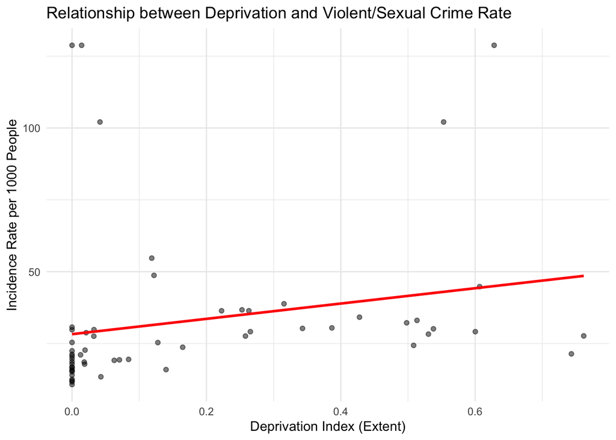

```r
# Calculate the incidence rate per LSOA
violent_crime_rate <- east_crimes |>
  st_drop_geometry() |>
  filter(type == "violent or sexual") |>
  group_by(GSS_CODE, Extent) |>
  summarise(
    violent_crimes = n(),
    population = first(Population) # Get the population for each LSOA
  ) %>%
  mutate(incidence_rate = violent_crimes / population * 1000) %>%
  ungroup()
# Plot the relationship between deprivation (Extent) and incidence rate
ggplot(violent_crime_rate, aes(x = Extent, y = incidence_rate)) +
  geom_point(alpha = 0.5, color = "black") +
  geom_smooth(method = "lm", color = "red", se = FALSE) +
  labs(
    title = "Relationship between Deprivation and Violent/Sexual Crime Rate",
    x = "Deprivation Index (Extent)",
    y = "Incidence Rate per 1000 People"
  ) +
  theme_minimal()
```

The figure above shows the relationship between the poverty index (Extent) and the incidence of violent/sexual crimes. As can be seen from the figure, as the poverty index increases, the incidence of violent/sexual crimes increases slightly, but the overall trend is relatively flat. This shows that within a certain range, the incidence of violent/sexual crimes may increase slightly in areas with higher poverty levels. However, the distribution of the data in the figure is relatively scattered, especially in areas with low poverty indexes (close to 0), where the incidence of violent/sexual crimes varies greatly. Therefore, although there is a certain positive correlation between the degree of poverty and the incidence of violent/sexual crimes, this relationship is also affected by other factors and needs to be further confirmed through statistical tests.

# Conclusion and limitation

Our analysis is based on crime data in 2022 and fails to take into account data trends in other years. In addition, although we analyzed the relationship between poverty level and crime rate, we did not consider other socioeconomic factors that may affect crime rate, such as unemployment rate, education level, etc. Uneven spatial distribution of data and limited sample size may also have affected the accuracy of the analysis results.